```r
library(readxl)
library(dplyr)
library(tidyr)
library(ggplot2)
library(patchwork)
```

```r
dat <- read_xlsx(here::here("data", "2021_chla-catalyst_data_all.xlsx"),
                 sheet = "qaqc") %>%
    mutate(extracted = chla_ugl,
           sensor_rfu = chlorophyll_rfu,
           sensor_ugl = chl_fluor,
           month = lubridate::month(datetime_collected)) %>%
    filter(!is.na(month))
```

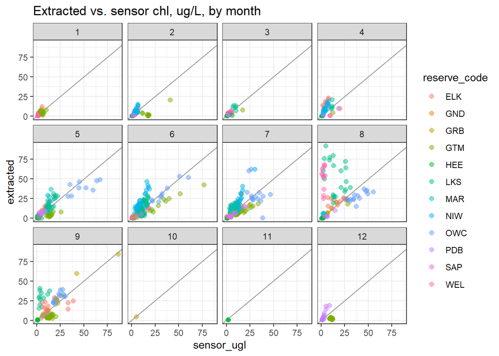

```r
ggplot(dat) +
    geom_abline(slope = 1, intercept = 0, col = "gray60") +
    geom_point(aes(x = sensor_ugl, y = extracted,
                   col = reserve_code),
               size = 2, alpha = 0.5) +
    facet_wrap(~month, ncol = 4) +
    # geom_smooth(aes(x = sensor_ugl, y = extracted)) +
    theme_bw() +
    labs(title = "Extracted vs. sensor chl, ug/L, by month")
```

# “Big” model

chl_extracted ~ sensor_rfu + turbidity + fdom + turb*fdom + temp + salinity + method + month + reserve

```r
fit_big <- lm(extracted ~ sensor_rfu + turb + fdom_qsu + turb*fdom_qsu + temp + sal + as.factor(method) + as.factor(month) + as.factor(reserve_code), data = dat)

broom::tidy(fit_big)
```

```
## # A tibble: 30 x 5
##    term                  estimate std.error statistic  p.value
##    <chr>                    <dbl>     <dbl>     <dbl>    <dbl>
##  1 (Intercept)            -1.30      2.92      -0.443 6.58e- 1
##  2 sensor_rfu              2.37      0.159     14.9   4.46e-45
##  3 turb                    0.104     0.0629     1.65  1.00e- 1
##  4 fdom_qsu               -0.0519    0.0174    -2.97  3.02e- 3
##  5 temp                    0.206     0.0791     2.61  9.23e- 3
##  6 sal                     0.0249    0.0687     0.362 7.17e- 1
##  7 as.factor(method)tank  -1.78      1.19      -1.50  1.35e- 1
##  8 as.factor(month)2       0.557     1.54       0.363 7.17e- 1
##  9 as.factor(month)3      -1.97      2.01      -0.983 3.26e- 1
## 10 as.factor(month)4       1.71      1.83       0.932 3.52e- 1
## # ... with 20 more rows
```

```r
broom::glance(fit_big)
```

```
## # A tibble: 1 x 12
##   r.squared adj.r.squared sigma statistic   p.value    df logLik   AIC   BIC
##       <dbl>         <dbl> <dbl>     <dbl>     <dbl> <dbl>  <dbl> <dbl> <dbl>
## 1     0.569         0.555  9.03      42.0 5.12e-147    29 -3434. 6931. 7081.
## # ... with 3 more variables: deviance <dbl>, df.residual <int>, nobs <int>
```

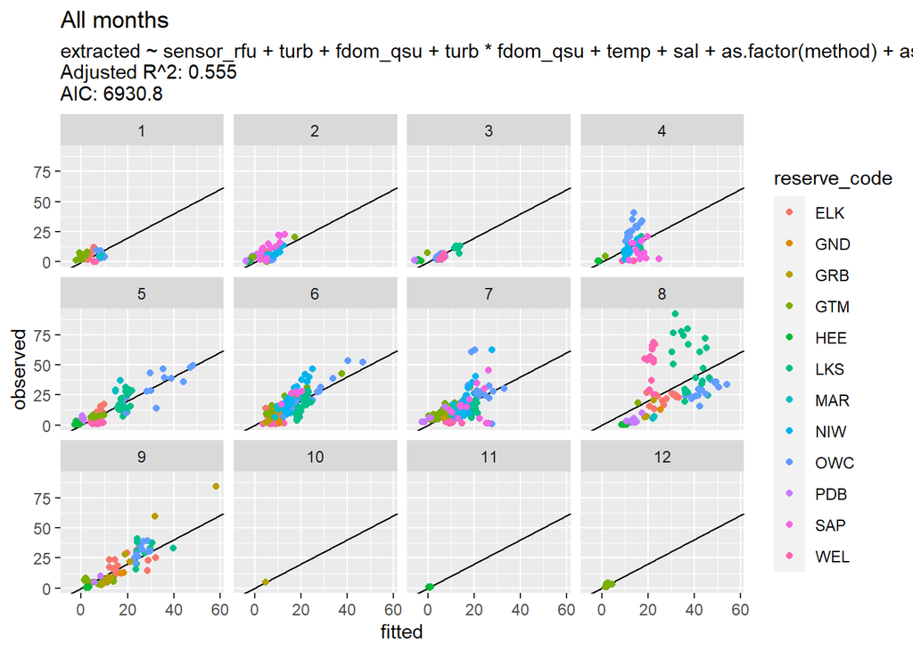

```r
fitted <- fitted.values(fit_big)
all_big <- dat %>%
    filter(!is.na(turb),
           !is.na(fdom_qsu),
           !is.na(sensor_rfu),
           !is.na(temp),
           !is.na(sal),
           !is.na(extracted))
all_big$fitted <- fitted.values(fit_big)

ggplot(all_big) +
    geom_abline(slope = 1, intercept = 0) +
    geom_point(aes(x = fitted, y = extracted, col = reserve_code)) +
    facet_wrap(~month, ncol = 4) +
    labs(x = "fitted",
         y = "observed",
         title = "All months",
         subtitle = paste(fit_big$call[2],
                          "\nAdjusted R^2:",
                          round(summary(fit_big)$adj.r.squared, 3),
                          "\nAIC:",
                          round(AIC(fit_big), 2)))
```

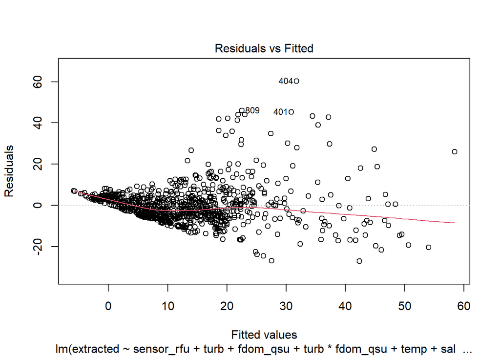

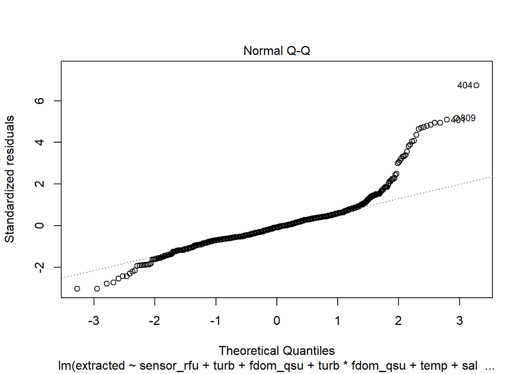

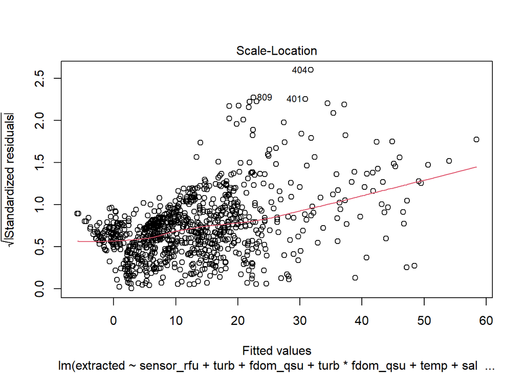

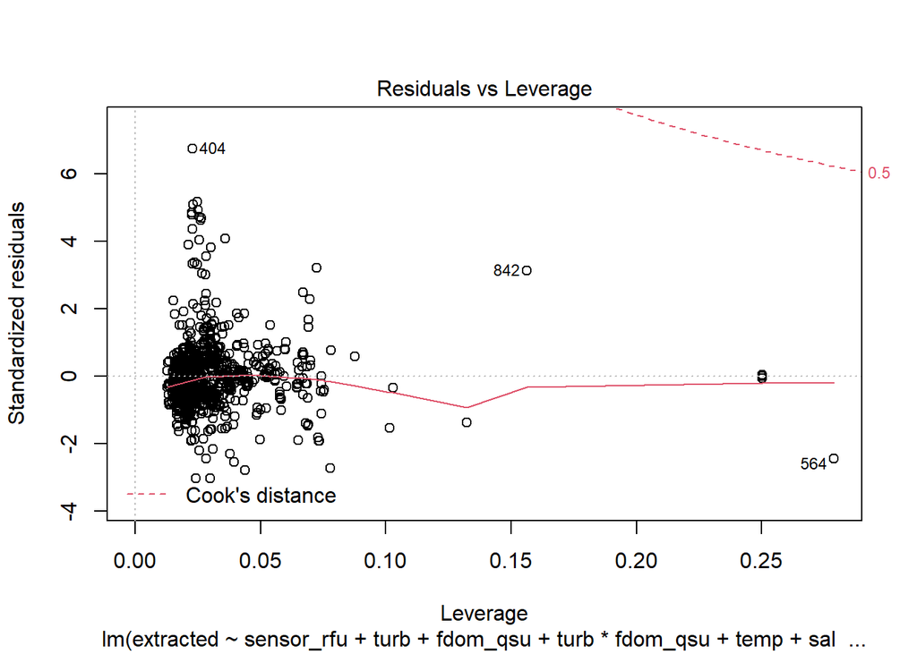

```r
plot(fit_big)
```

Residuals vs. fitted plot for the big fit above makes a funnel. Sometimes transforming the response can help……

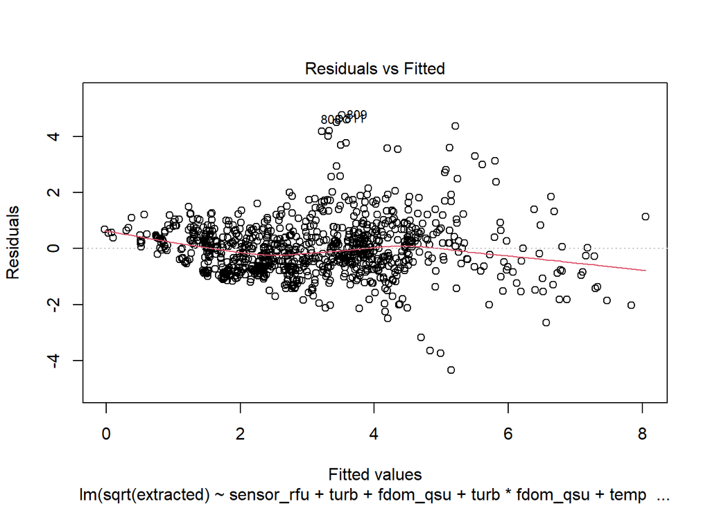

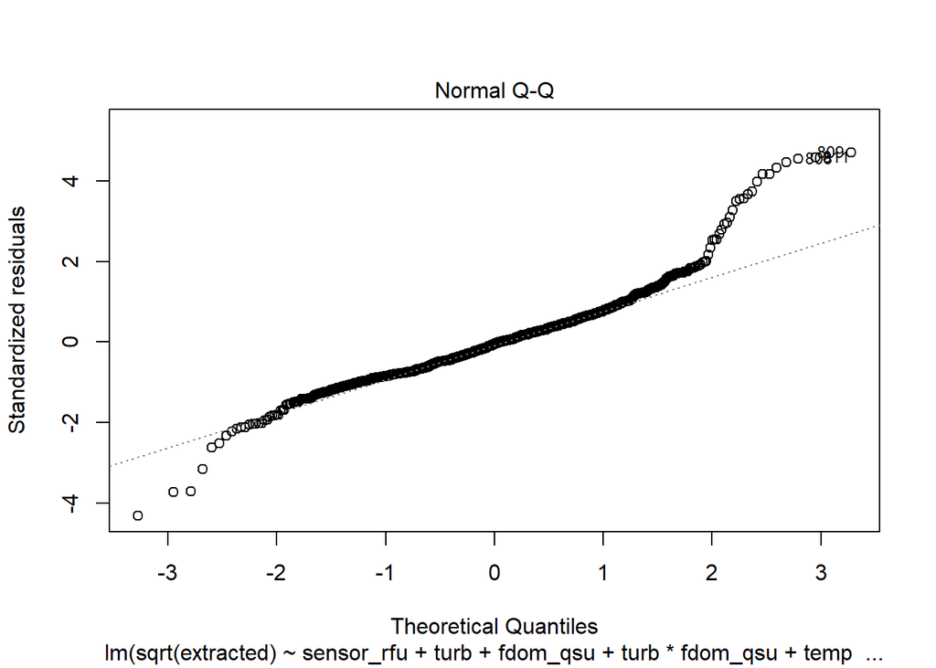

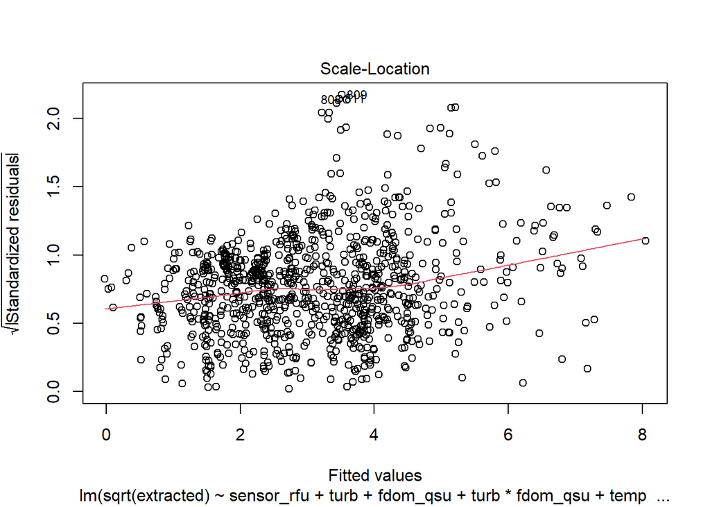

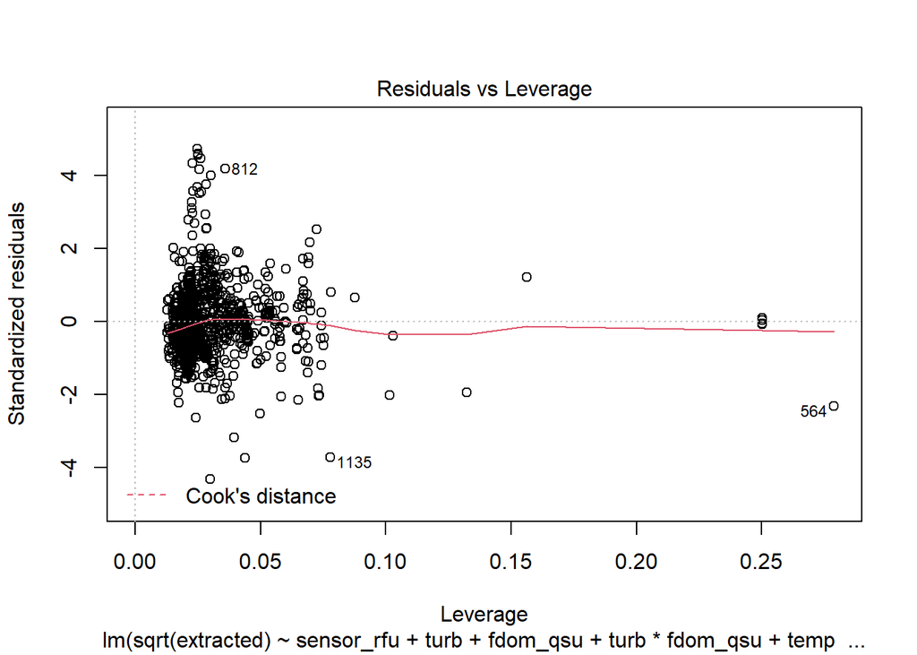

```r
fit_big_sqrt <- lm(sqrt(extracted) ~ sensor_rfu + turb + fdom_qsu + turb*fdom_qsu + temp + sal + as.factor(method) +as.factor(month) + as.factor(reserve_code), data = dat)

plot(fit_big_sqrt)
```

Square root transformation helps a lot, actually. Hm. Not for normality, but for the funneling, definitely.

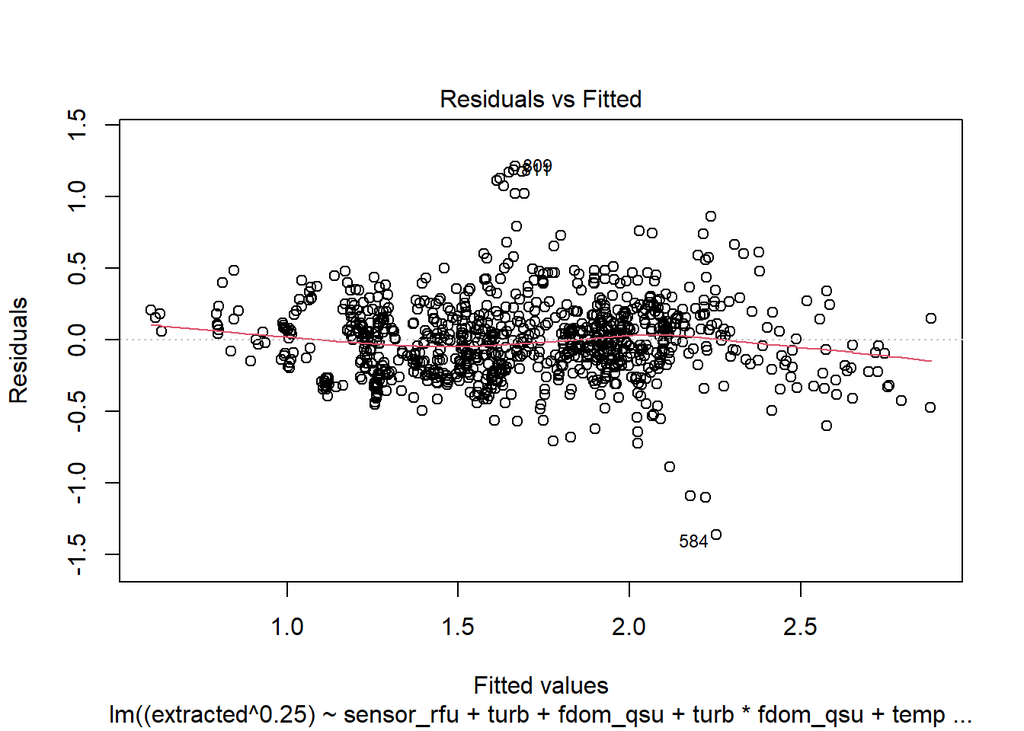

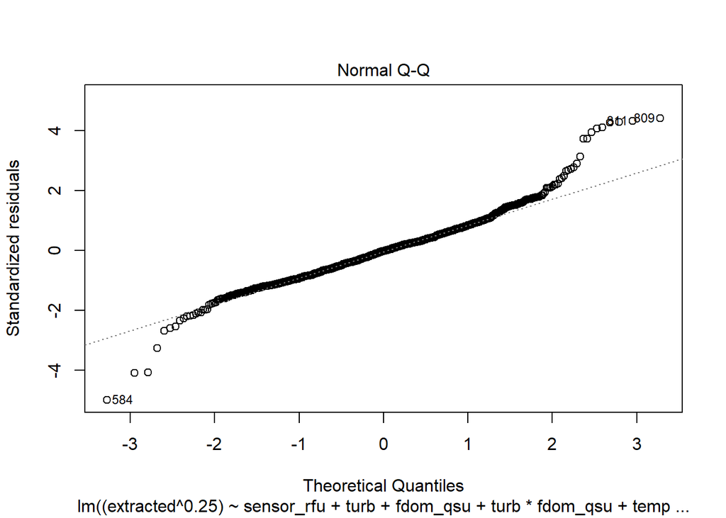

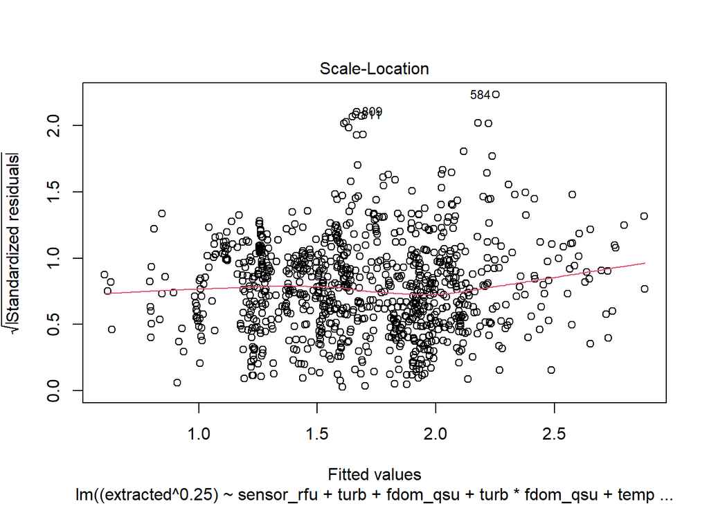

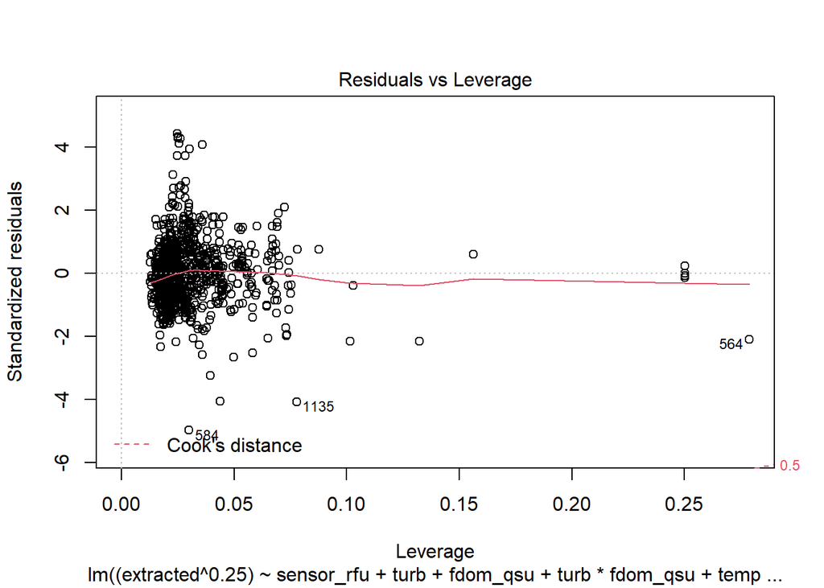

```r
fit_big_frthrt <- lm((extracted^0.25) ~ sensor_rfu + turb + fdom_qsu + turb*fdom_qsu + temp + sal + as.factor(method) + as.factor(month) + as.factor(reserve_code), data = dat)

plot(fit_big_frthrt)
```

Don’t think a fourth-root does any better than square-root. Maybe a little, when it comes to the funneling of residuals.

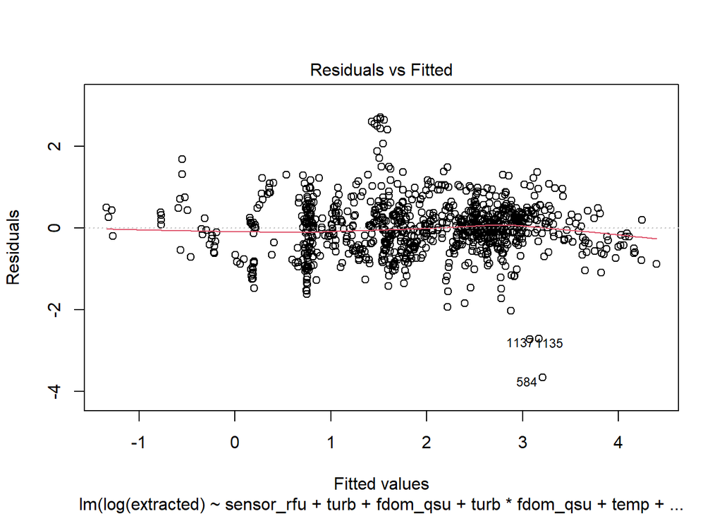

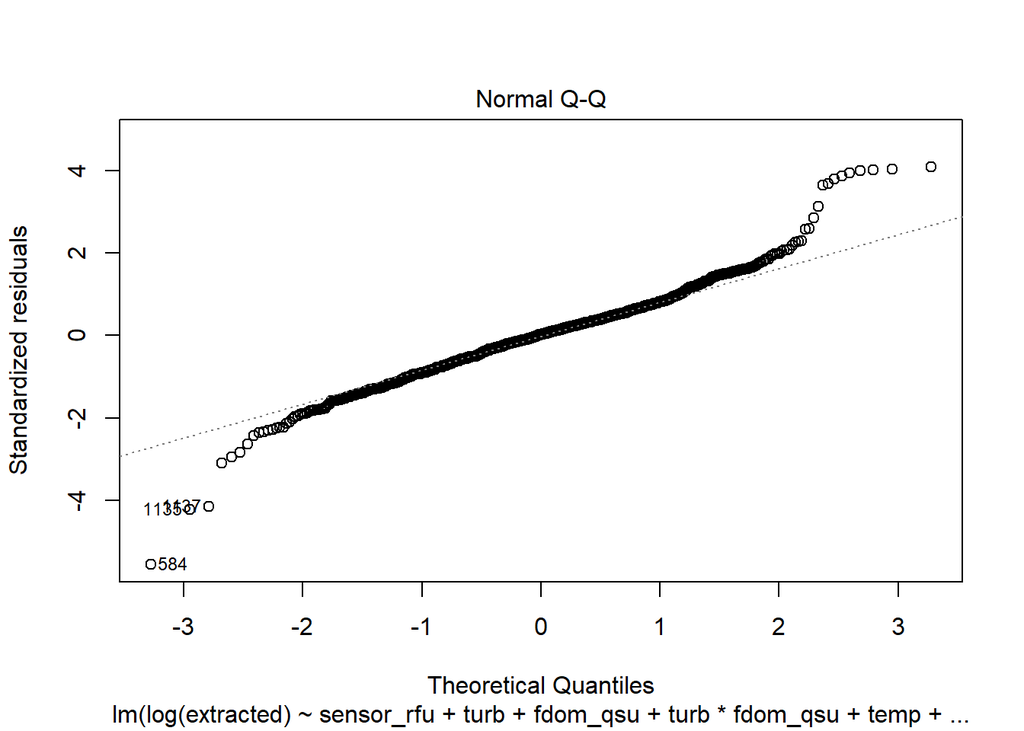

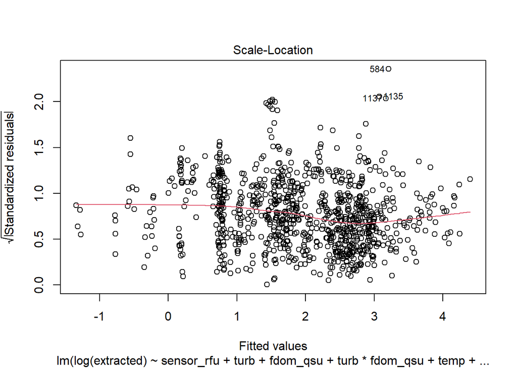

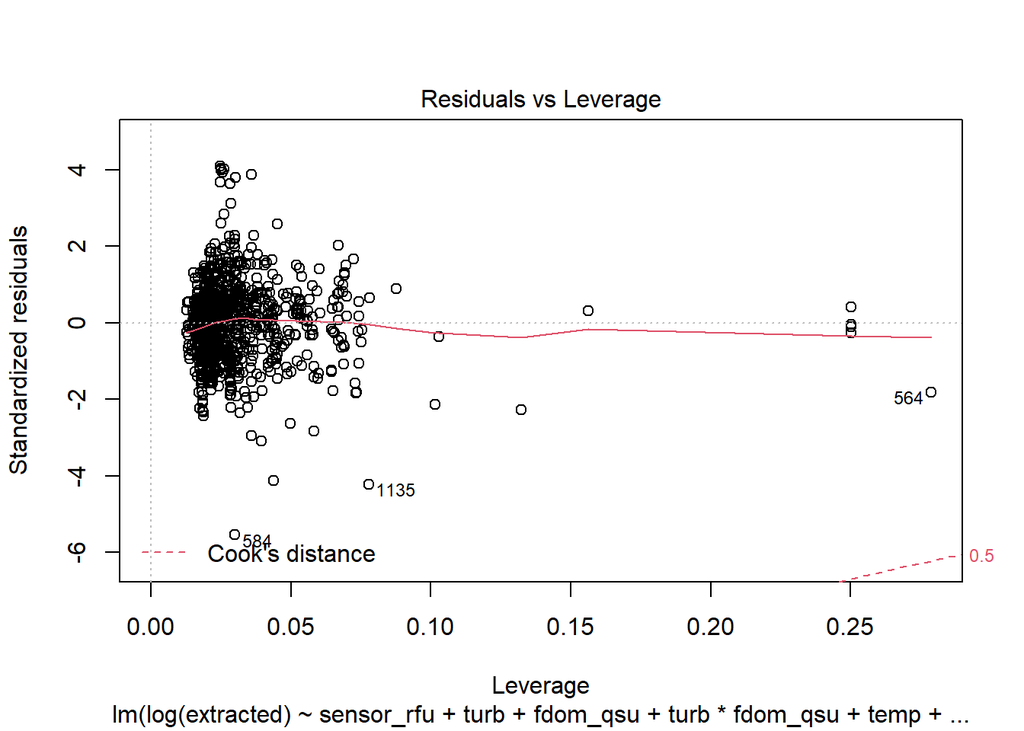

```r
fit_big_log <- lm(log(extracted) ~ sensor_rfu + turb + fdom_qsu + turb*fdom_qsu + temp + sal + as.factor(method) + as.factor(month) + as.factor(reserve_code), data = dat)

plot(fit_big_log)
```

Comparable to fourth-root, I think….. if I had to choose between the two, I’d choose fourth-root over log because log(0) doesn’t exist and that could cause problems down the road.

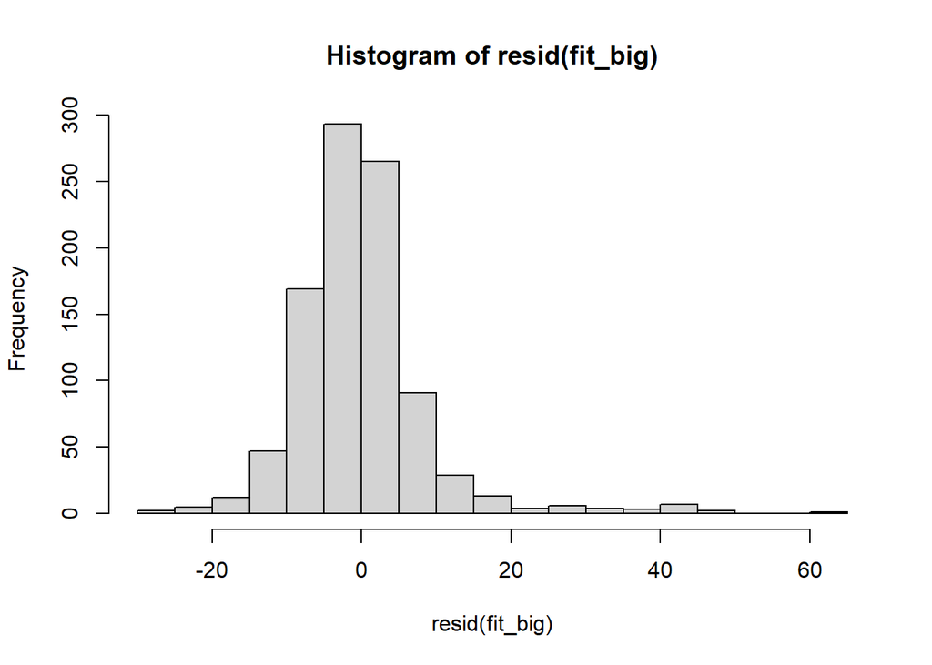

```r
hist(resid(fit_big), breaks = 30)
```

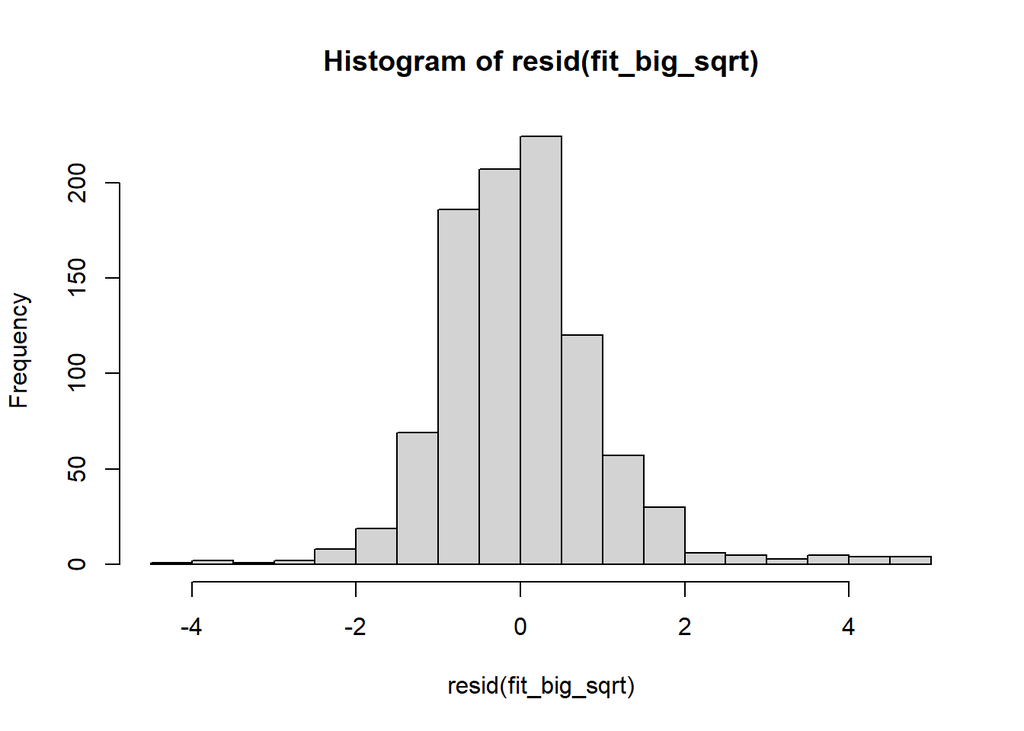

```r
hist(resid(fit_big_sqrt), breaks = 30)
```

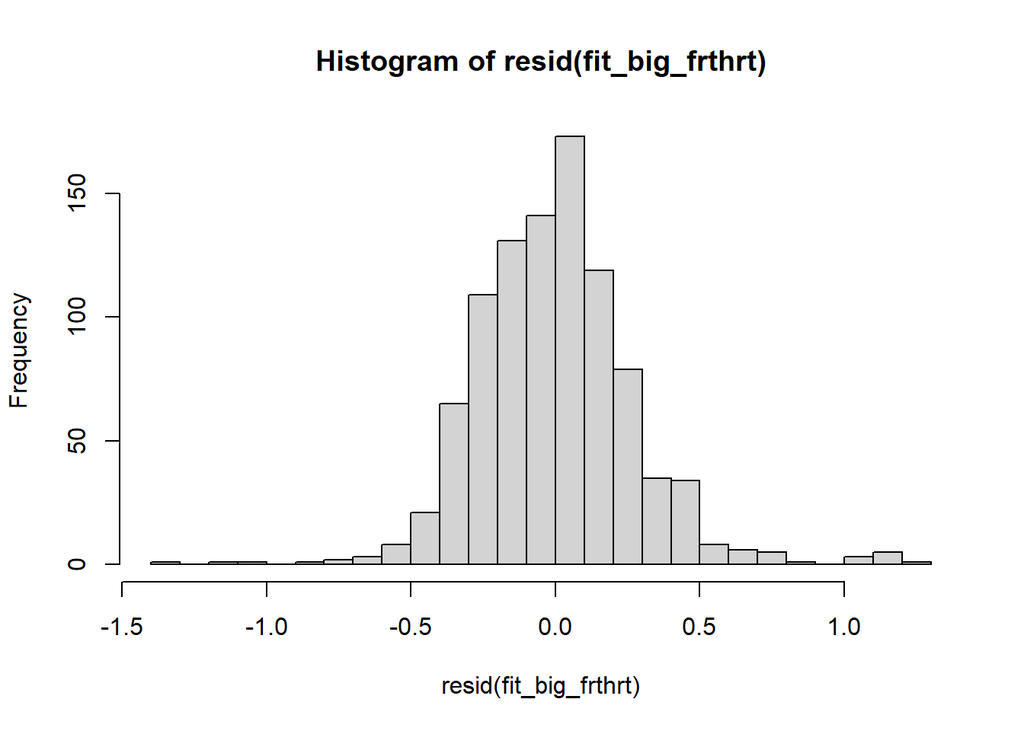

```r
hist(resid(fit_big_frthrt), breaks = 30)
```

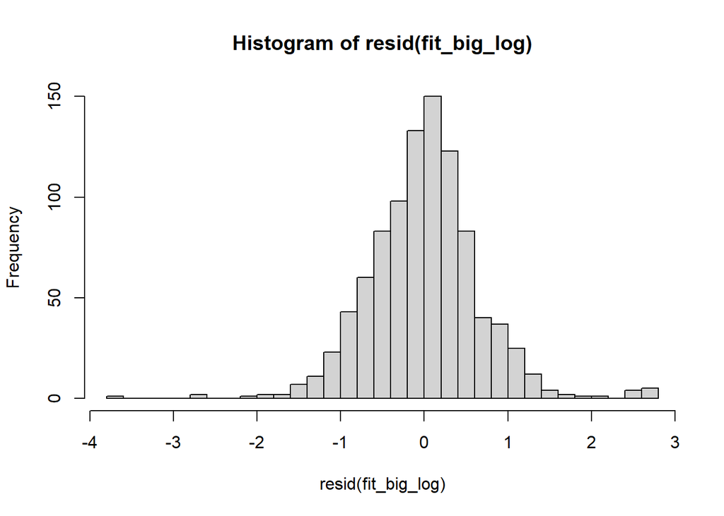

```r
hist(resid(fit_big_log), breaks = 30)
```

Log may help a little more than square root with normality of residuals, but could potentially be more complicated for the end user.

Add predicted values into data frame:

```r
all_big$fitted_log <- exp(fitted.values(fit_big_log))
all_big$fitted_sqrt <- (fitted.values(fit_big_sqrt))^2
all_big$fitted_frthrt <- (fitted.values(fit_big_frthrt))^4
```

Plot the fits by observed:

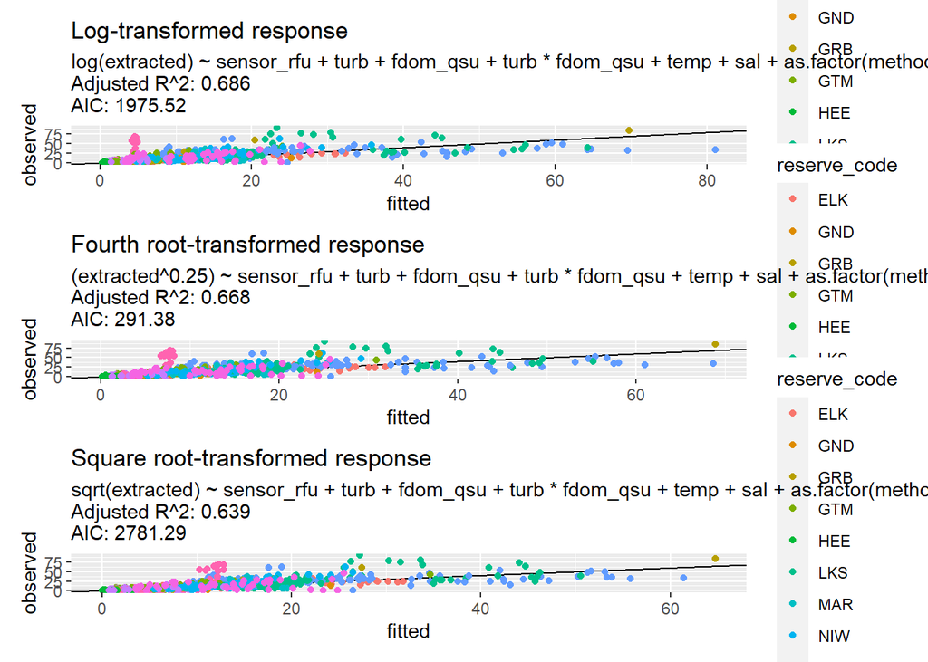

```r
p1 <- ggplot(all_big) +
    geom_abline(slope = 1, intercept = 0) +
    geom_point(aes(x = fitted_log, y = extracted, col = reserve_code)) +
    labs(x = "fitted",
         y = "observed",
         title = "Log-transformed response",
         subtitle = paste(fit_big_log$call[2],
                          "\nAdjusted R^2:",
                          round(summary(fit_big_log)$adj.r.squared, 3),
                          "\nAIC:",
                          round(AIC(fit_big_log), 2)))

p2 <- ggplot(all_big) +
    geom_abline(slope = 1, intercept = 0) +
    geom_point(aes(x = fitted_frthrt, y = extracted, col = reserve_code)) +
    labs(x = "fitted",
         y = "observed",
         title = "Fourth root-transformed response",
         subtitle = paste(fit_big_frthrt$call[2],
                          "\nAdjusted R^2:",
                          round(summary(fit_big_frthrt)$adj.r.squared, 3),
                          "\nAIC:",
                          round(AIC(fit_big_frthrt), 2)))


p3 <- ggplot(all_big) +
    geom_abline(slope = 1, intercept = 0) +
    geom_point(aes(x = fitted_sqrt, y = extracted, col = reserve_code)) +
    labs(x = "fitted",
         y = "observed",
         title = "Square root-transformed response",
         subtitle = paste(fit_big_sqrt$call[2],
                          "\nAdjusted R^2:",
                          round(summary(fit_big_sqrt)$adj.r.squared, 3),
                          "\nAIC:",
                          round(AIC(fit_big_sqrt), 2)))

p1 / p2 / p3
```

Square root is still my favorite, especially looking at how the predictions come out. The high outliers come out closest to “true” (though still pretty low), and the scatter around the 1:1 line is better towards the high end than with the others.

All of the transformations cut off predictions at 0, which the untransformed model didn’t do (I don’t remember if I even graphed that one? There were negative predicted values at the low end of the rfu readings.)

Let’s look more closely at the square-root transformation’s predictions, by month:

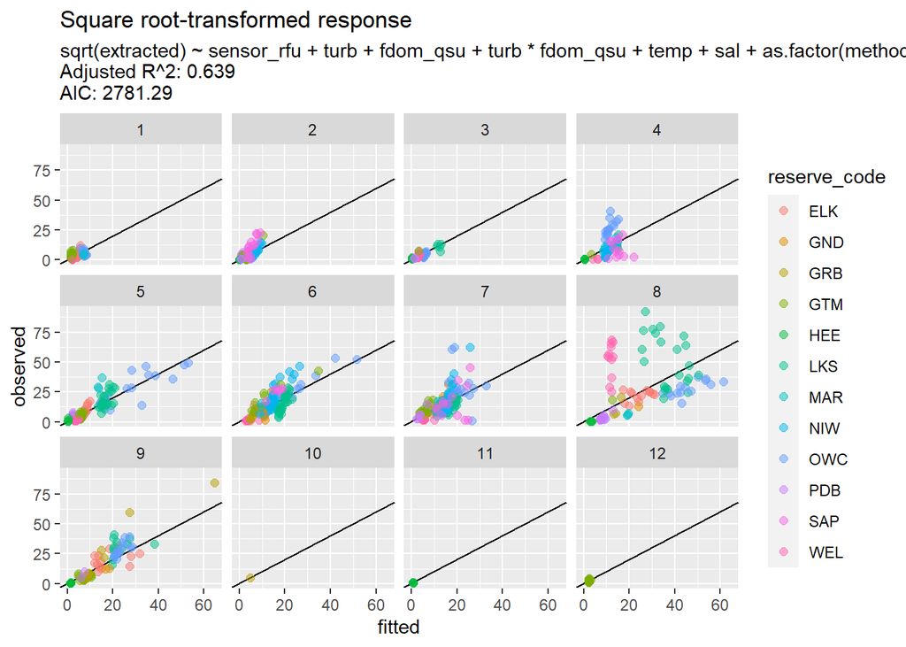

```r
ggplot(all_big) +
    geom_abline(slope = 1, intercept = 0) +
    geom_point(aes(x = fitted_sqrt, y = extracted, col = reserve_code),
               size = 2, alpha = 0.5) +
    facet_wrap(~month, ncol = 4) +
    labs(x = "fitted",
         y = "observed",
         title = "Square root-transformed response",
         subtitle = paste(fit_big_sqrt$call[2],
                          "\nAdjusted R^2:",
                          round(summary(fit_big_sqrt)$adj.r.squared, 3),
                          "\nAIC:",
                          round(AIC(fit_big_sqrt), 2)))
```

It does better for August than the other models do.

### Root Mean Square Error

….of predictions. In `summary(fit)`, `Residual Standard Error` = `sigma` (`broom::glance` output) = RMSE of model. When the response variable was transformed, *this sigma was on the transformed scale*. So here I’ll calculate RMSE for predictions that have been back-transformed to the original scale.

```r
rmse_fun <- function(observed, predicted){
    # check to make sure vectors are the same length

    # something about NAs - don't want any

    sqrt(mean((predicted - observed)^2))
}
```

```r
(rmse_big_fit <- rmse_fun(all_big$extracted, all_big$fitted))
```

```
## [1] 8.889215
```

```r
(rmse_log_fit <- rmse_fun(all_big$extracted, all_big$fitted_log))
```

```
## [1] 10.31635
```

```r
(rmse_frthrt_fit <- rmse_fun(all_big$extracted, all_big$fitted_frthrt))
```

```
## [1] 9.712365
```

```r
(rmse_sqrt_fit <- rmse_fun(all_big$extracted, all_big$fitted_sqrt))
```

```
## [1] 9.238717
```

Of the transformed ones, square-root does the best. Not too much worse than the untransformed model.

ALRIGHT. So square-root is the way to go.

### more residual checks

After all that, make plots of residuals by each predictor, just to make sure all’s well.

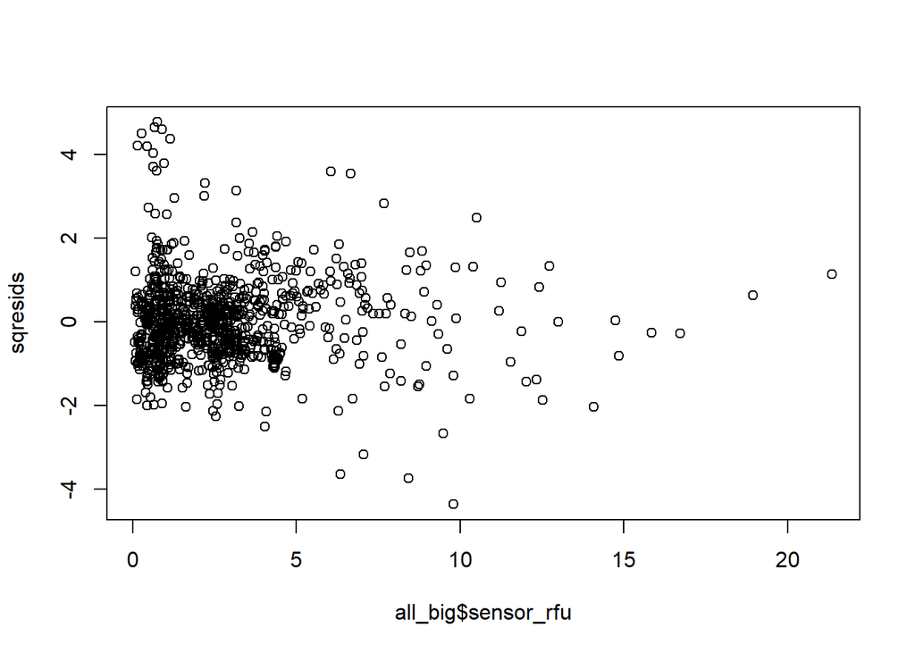

```r
sqresids <- resid(fit_big_sqrt)

plot(sqresids ~ all_big$sensor_rfu)
```

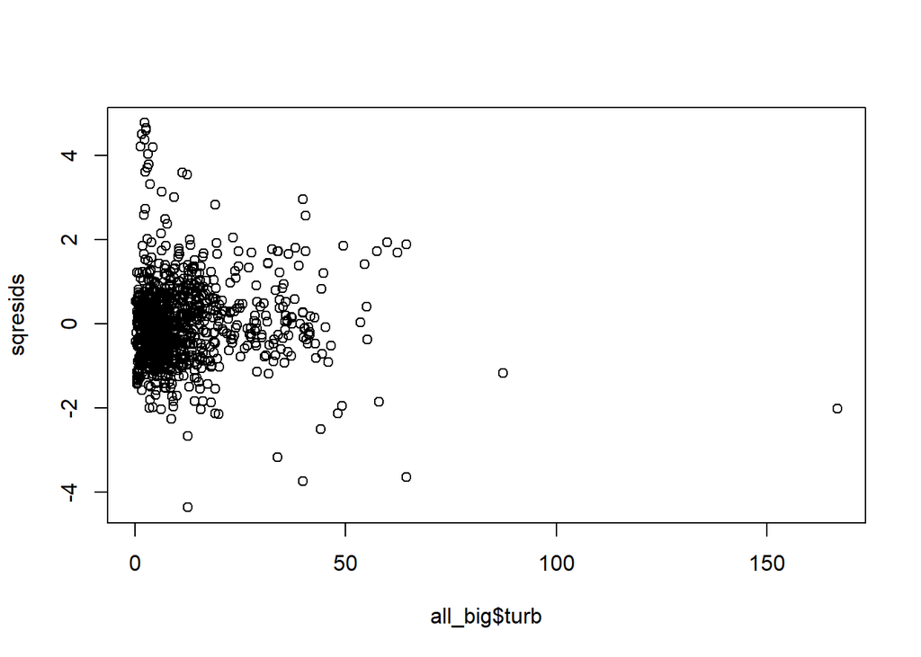

```r
plot(sqresids ~ all_big$turb)
```

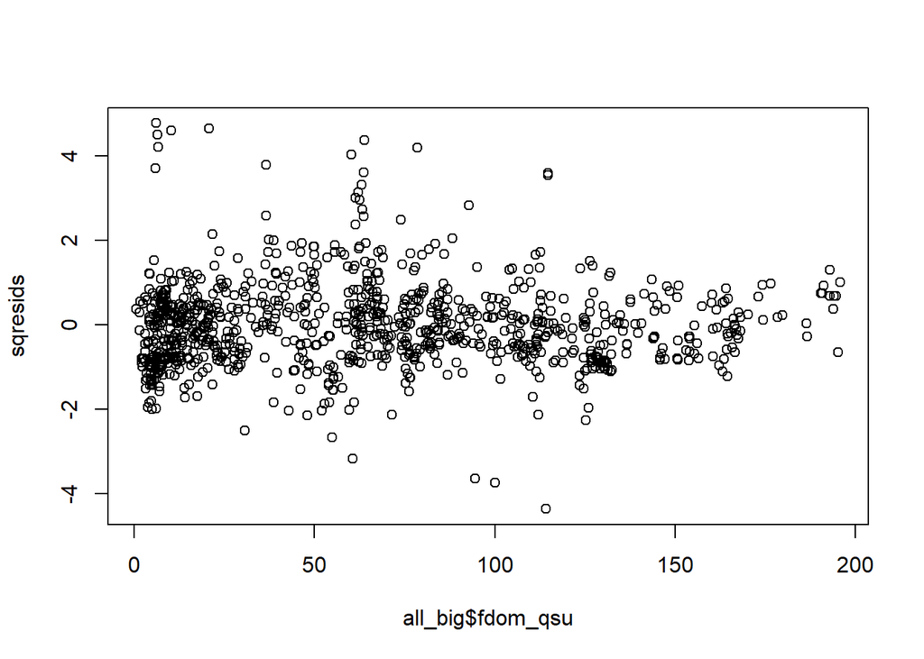

```r
plot(sqresids ~ all_big$fdom_qsu)
```

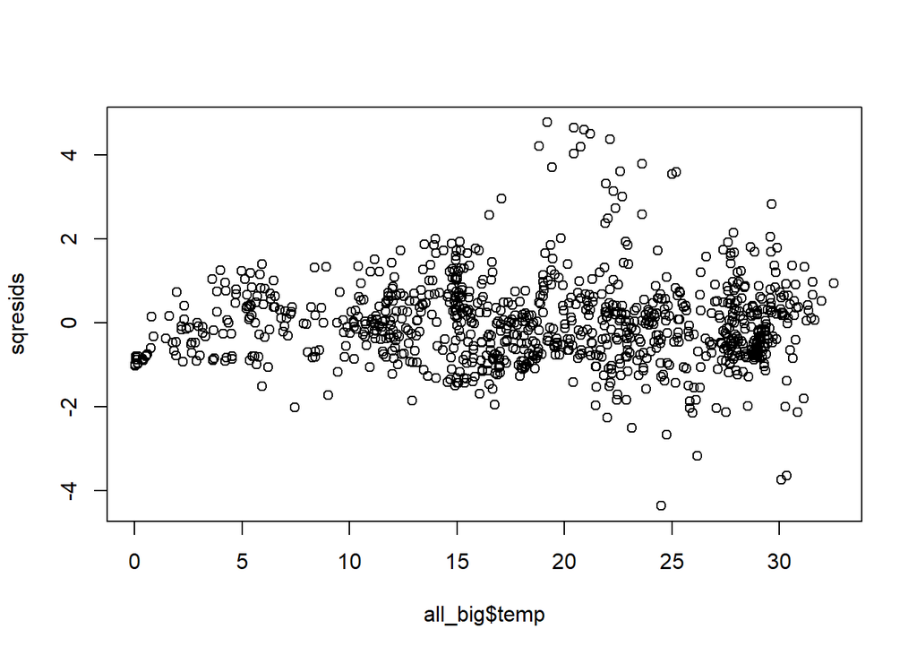

```r
plot(sqresids ~ all_big$temp)
```

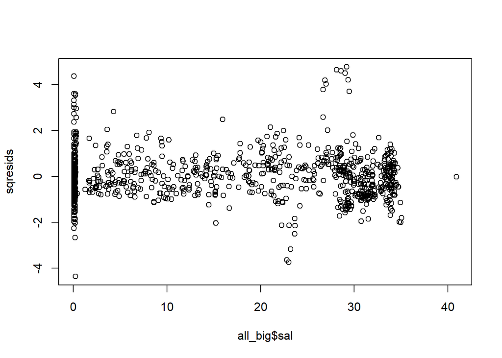

```r
plot(sqresids ~ all_big$sal)
```

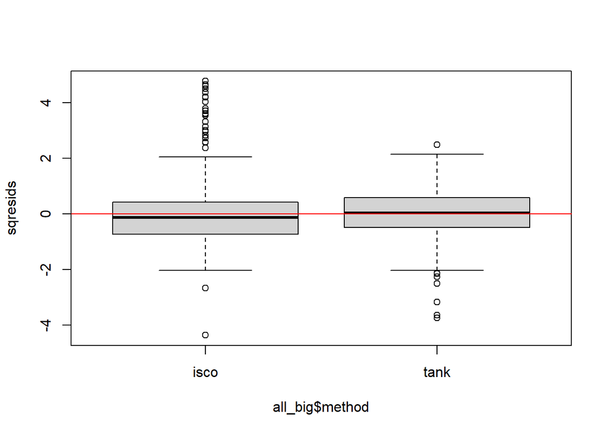

```r
boxplot(sqresids ~ all_big$method)
abline(h = 0, col = "red")
```

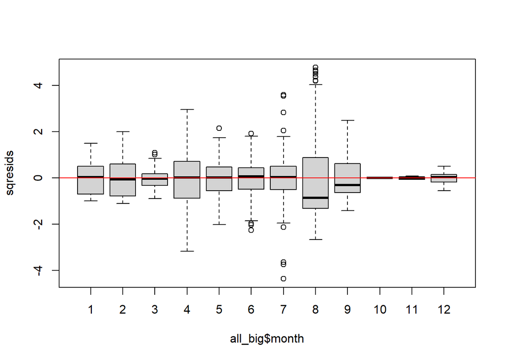

```r
boxplot(sqresids ~ all_big$month)
abline(h = 0, col = "red")
```

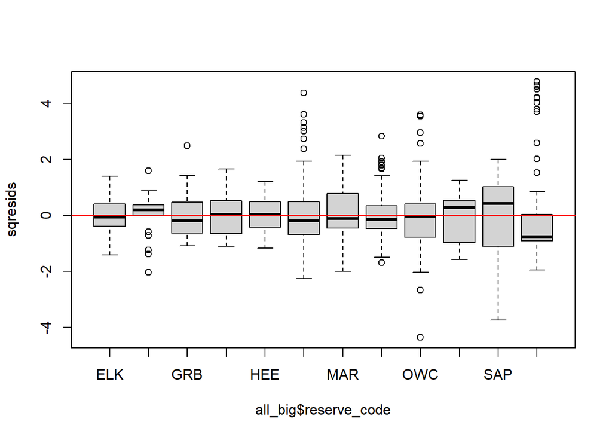

```r
boxplot(sqresids ~ all_big$reserve_code)
abline(h = 0, col = "red")
```

# Tank vs. ISCO

Do I need to keep ‘method’ in the model? Before proceeding with other model fitting, need to find out. Would be great if I don’t need it.

```r
fit_reduced <- lm(sqrt(extracted) ~ sensor_rfu + turb + fdom_qsu + turb*fdom_qsu + temp + sal + as.factor(month) + as.factor(reserve_code), data = dat)
```

### Diagnostics - full model

```r
broom::glance(fit_big_sqrt)
```

```
## # A tibble: 1 x 12
##   r.squared adj.r.squared sigma statistic   p.value    df logLik   AIC   BIC
##       <dbl>         <dbl> <dbl>     <dbl>     <dbl> <dbl>  <dbl> <dbl> <dbl>
## 1     0.650         0.639  1.02      59.2 3.96e-188    29 -1360. 2781. 2932.
## # ... with 3 more variables: deviance <dbl>, df.residual <int>, nobs <int>
```

### Diagnostics - reduced model

(method removed)

```r
broom::glance(fit_reduced)
```

```
## # A tibble: 1 x 12
##   r.squared adj.r.squared sigma statistic   p.value    df logLik   AIC   BIC
##       <dbl>         <dbl> <dbl>     <dbl>     <dbl> <dbl>  <dbl> <dbl> <dbl>
## 1     0.650         0.640  1.02      61.3 6.01e-189    28 -1360. 2780. 2925.
## # ... with 3 more variables: deviance <dbl>, df.residual <int>, nobs <int>
```

```r
AIC(fit_big_sqrt, fit_reduced)
```

```
##              df      AIC
## fit_big_sqrt 31 2781.292
## fit_reduced  30 2779.673
```

Essentially the same fit. We don’t need to include method for tank vs. isco. Hooray!

# Simplest models - sensor values only

Unsure if there’s a difference between sensor RFU and sensor ug/L predictive ability - based on pairs plots, seems like there’s pretty much a 1:1 correlation. But to be sure, let’s only use rows where both exist.

```r
sensor_all <- dat %>%
    select(reserve_code, extracted,
           sensor_rfu, sensor_ugl) %>%
    drop_na()

fit_rfu <- lm(extracted ~ sensor_rfu, data = sensor_all)
fit_ugl <- lm(extracted ~ sensor_ugl, data = sensor_all)

broom::glance(fit_rfu)
```

```
## # A tibble: 1 x 12
##   r.squared adj.r.squared sigma statistic  p.value    df logLik   AIC   BIC
##       <dbl>         <dbl> <dbl>     <dbl>    <dbl> <dbl>  <dbl> <dbl> <dbl>
## 1     0.287         0.286  11.4      377. 8.70e-71     1 -3614. 7234. 7248.
## # ... with 3 more variables: deviance <dbl>, df.residual <int>, nobs <int>
```

```r
broom::glance(fit_ugl)
```

```
## # A tibble: 1 x 12
##   r.squared adj.r.squared sigma statistic  p.value    df logLik   AIC   BIC
##       <dbl>         <dbl> <dbl>     <dbl>    <dbl> <dbl>  <dbl> <dbl> <dbl>
## 1     0.290         0.289  11.4      382. 1.37e-71     1 -3612. 7230. 7244.
## # ... with 3 more variables: deviance <dbl>, df.residual <int>, nobs <int>
```

```r
broom::tidy(fit_rfu)
```

```
## # A tibble: 2 x 5
##   term        estimate std.error statistic  p.value
##   <chr>          <dbl>     <dbl>     <dbl>    <dbl>
## 1 (Intercept)     4.56     0.530      8.61 3.00e-17
## 2 sensor_rfu      2.84     0.146     19.4  8.70e-71
```

```r
broom::tidy(fit_ugl)
```

```
## # A tibble: 2 x 5
##   term        estimate std.error statistic  p.value
##   <chr>          <dbl>     <dbl>     <dbl>    <dbl>
## 1 (Intercept)    4.50     0.530       8.48 8.66e-17
## 2 sensor_ugl     0.714    0.0366     19.5  1.37e-71
```

Some teeny differences but I suspect that’s due to units and rounding. So I’ll keep using rfu moving forward.

# Other EDA

### When is data missing?

```r
subdat <- dat %>%
    select(reserve_code, month, method,
           extracted, sensor_rfu, sensor_ugl,
           temp, sal, fdom_qsu, fdom_rfu,
           turb)
summary(subdat)
```

```
##  reserve_code           month          method            extracted
##  Length:1143        Min.   : 1.00   Length:1143        Min.   : 0.00835
##  Class :character   1st Qu.: 4.00   Class :character   1st Qu.: 2.20735
##  Mode  :character   Median : 6.00   Mode  :character   Median : 6.29321
##                     Mean   : 5.59                      Mean   :11.09185
##                     3rd Qu.: 7.00                      3rd Qu.:15.34000
##                     Max.   :12.00                      Max.   :92.01000
##                                                        NA's   :20
##    sensor_rfu        sensor_ugl          temp             sal
##  Min.   : 0.0500   Min.   : 0.270   Min.   : 0.019   Min.   : 0.08
##  1st Qu.: 0.8185   1st Qu.: 2.553   1st Qu.:12.903   1st Qu.: 0.27
##  Median : 2.0100   Median : 7.651   Median :19.300   Median :21.32
##  Mean   : 2.5508   Mean   : 9.719   Mean   :18.661   Mean   :17.87
##  3rd Qu.: 3.2700   3rd Qu.:12.675   3rd Qu.:25.811   3rd Qu.:31.01
##  Max.   :21.3593   Max.   :86.437   Max.   :32.529   Max.   :40.91
##  NA's   :79        NA's   :119      NA's   :2        NA's   :2
##     fdom_qsu           fdom_rfu            turb
##  Min.   :  0.5275   Min.   : 0.4518   Min.   :  0.111
##  1st Qu.: 15.7700   1st Qu.: 5.6465   1st Qu.:  3.190
##  Median : 59.6900   Median :20.0600   Median :  6.850
##  Mean   : 63.3916   Mean   :21.4316   Mean   : 10.684
##  3rd Qu.:100.6488   3rd Qu.:33.8050   3rd Qu.: 12.950
##  Max.   :195.7463   Max.   :64.9887   Max.   :243.830
##  NA's   :162        NA's   :196       NA's   :10
```

What’s up with the NAs for extracted?

```r
subdat %>%
    filter(is.na(extracted)) %>%
    knitr::kable()
```

| reserve_code | month | method | extracted | sensor_rfu | sensor_ugl | temp | sal | fdom_qsu | fdom_rfu | turb |
| --- | --- | --- | --- | --- | --- | --- | --- | --- | --- | --- |
| LKS | 6 | isco | NA | NA | NA | NA | NA | NA | NA | NA |
| LKS | 6 | isco | NA | NA | NA | NA | NA | NA | NA | NA |
| OWC | 2 | isco | NA | 0.7600000 | NA | 0.09800 | 0.18 | 7.920000 | 2.520000 | 15.970000 |
| WEL | 4 | isco | NA | 2.1300000 | 8.58000 | 7.94200 | 29.60 | 9.020000 | 2.930000 | 7.920000 |
| WEL | 4 | isco | NA | 1.9900000 | 7.99000 | 9.54500 | 28.35 | 15.520000 | 5.100000 | 8.220000 |
| WEL | 4 | isco | NA | 2.1500000 | 8.64000 | 9.67200 | 27.95 | 17.820000 | 5.870000 | 7.590000 |
| WEL | 4 | isco | NA | 0.1900000 | 0.81000 | 7.15000 | 30.26 | 5.920000 | 1.900000 | 7.970000 |
| WEL | 4 | isco | NA | 1.8200000 | 7.34000 | 7.20200 | 30.24 | 5.150000 | 1.640000 | 7.400000 |
| WEL | 4 | isco | NA | 2.7900000 | 11.19000 | 7.20000 | 30.30 | 4.420000 | 1.390000 | 7.290000 |
| WEL | 4 | isco | NA | 2.7000000 | 10.85000 | 8.92500 | 28.66 | 12.710000 | 4.160000 | 6.980000 |
| WEL | 4 | isco | NA | 0.4500000 | 1.84000 | 6.01000 | 30.94 | 4.700000 | 1.490000 | 7.190000 |
| WEL | 4 | isco | NA | 2.3300000 | 9.35000 | 6.01400 | 30.39 | 5.620000 | 1.800000 | 7.560000 |
| LKS | 5 | tank | NA | 5.4280000 | 21.78800 | 17.05120 | 0.08 | 155.942000 | 51.790000 | 6.236000 |
| LKS | 5 | tank | NA | 2.8920000 | 11.54800 | 16.97580 | 0.08 | 155.672000 | 51.700000 | 6.142000 |
| LKS | 5 | tank | NA | 9.3100000 | 37.46800 | 17.42040 | 0.08 | 155.346000 | 51.588000 | 6.416000 |
| LKS | 5 | tank | NA | 6.9250000 | 27.91833 | 13.99800 | 0.09 | 195.458333 | 64.891667 | 9.258333 |
| LKS | 5 | tank | NA | 4.4750000 | 18.03625 | 15.93450 | 0.09 | 184.720000 | 61.330000 | 8.526250 |
| MAR | 2 | tank | NA | 0.7525424 | NA | 16.33356 | 30.12 | 9.900000 | 3.980000 | 17.785424 |
| MAR | 2 | tank | NA | 1.1670492 | NA | 16.29000 | 29.97 | 8.820820 | 3.600000 | 17.120000 |
| MAR | 2 | tank | NA | 1.4426230 | NA | 15.84107 | 29.70 | 9.275574 | 3.757213 | 26.391475 |

*sigh* mostly qa/qc decisions; numbers are there in the raw spreadsheet and some of the ones missing an extracted value have really high FDOM but were rejected because the stirbar stopped spinning. Personally I"m not convinced that’s enough to chuck the numbers but I guess the decision isn’t mine.

So what does the summary look like if we remove the rows where there’s no extracted data?

```r
subdat %>%
    filter(!is.na(extracted)) %>%
    summary()
```

```
##  reserve_code           month           method            extracted
##  Length:1123        Min.   : 1.000   Length:1123        Min.   : 0.00835
##  Class :character   1st Qu.: 4.000   Class :character   1st Qu.: 2.20735
##  Mode  :character   Median : 6.000   Mode  :character   Median : 6.29321
##                     Mean   : 5.617                      Mean   :11.09185
##                     3rd Qu.: 7.000                      3rd Qu.:15.34000
##                     Max.   :12.000                      Max.   :92.01000
##
##    sensor_rfu        sensor_ugl          temp             sal
##  Min.   : 0.0500   Min.   : 0.270   Min.   : 0.019   Min.   : 0.080
##  1st Qu.: 0.8156   1st Qu.: 2.522   1st Qu.:13.040   1st Qu.: 0.285
##  Median : 2.0058   Median : 7.600   Median :19.548   Median :21.190
##  Mean   : 2.5471   Mean   : 9.672   Mean   :18.782   Mean   :17.843
##  3rd Qu.: 3.2700   3rd Qu.:12.665   3rd Qu.:25.932   3rd Qu.:31.075
##  Max.   :21.3593   Max.   :86.437   Max.   :32.529   Max.   :40.908
##  NA's   :77        NA's   :113
##     fdom_qsu           fdom_rfu            turb
##  Min.   :  0.5275   Min.   : 0.4518   Min.   :  0.111
##  1st Qu.: 16.3750   1st Qu.: 5.7800   1st Qu.:  3.180
##  Median : 60.5921   Median :20.1500   Median :  6.780
##  Mean   : 63.5755   Mean   :21.5008   Mean   : 10.693
##  3rd Qu.:100.5694   3rd Qu.:33.7000   3rd Qu.: 12.965
##  Max.   :195.7463   Max.   :64.9887   Max.   :243.830
##  NA's   :160        NA's   :194       NA's   :8
```

Let’s see what’s missing in sensor_rfu:

```r
subdat %>%
    filter(!is.na(extracted),
           is.na(sensor_rfu)) %>%
    knitr::kable()
```

| reserve_code | month | method | extracted | sensor_rfu | sensor_ugl | temp | sal | fdom_qsu | fdom_rfu | turb |
| --- | --- | --- | --- | --- | --- | --- | --- | --- | --- | --- |
| HEE | 2 | isco | 0.4300000 | NA | 0.67 | 20.91900 | 34.47000 | NA | NA | 1.480000 |
| HEE | 2 | isco | 0.3400000 | NA | 0.61 | 22.36400 | 34.53000 | NA | NA | 1.030000 |
| HEE | 2 | isco | 0.3000000 | NA | 0.63 | 24.32500 | 34.75000 | NA | NA | 0.710000 |
| HEE | 2 | isco | 0.5200000 | NA | 0.80 | 24.13000 | 34.51000 | NA | NA | 1.630000 |
| HEE | 2 | isco | 0.4600000 | NA | 0.85 | 23.86100 | 34.51000 | NA | NA | 2.590000 |
| HEE | 2 | isco | 0.4100000 | NA | 1.06 | 22.86000 | 34.11000 | NA | NA | 7.970000 |
| HEE | 2 | isco | 0.3700000 | NA | 1.39 | 22.37200 | 34.35000 | NA | NA | 5.930000 |
| HEE | 2 | isco | 0.8000000 | NA | 1.36 | 23.15200 | 34.71000 | NA | NA | 5.580000 |
| HEE | 2 | isco | 0.6900000 | NA | 1.63 | 23.18400 | 34.82000 | NA | NA | 1.610000 |
| HEE | 2 | isco | 0.4300000 | NA | 0.93 | 22.45500 | 34.11000 | NA | NA | 1.230000 |
| HEE | 2 | isco | 0.6000000 | NA | 1.05 | 22.12600 | 34.27000 | NA | NA | 1.710000 |
| HEE | 2 | isco | 0.3600000 | NA | 0.79 | 22.08300 | 34.39000 | NA | NA | 1.090000 |
| HEE | 3 | isco | 2.0000000 | NA | 2.75 | 24.64700 | 30.22000 | NA | NA | 3.310000 |
| HEE | 3 | isco | 1.3700000 | NA | 1.26 | 26.58800 | 32.13000 | NA | NA | 2.300000 |
| HEE | 3 | isco | 0.2000000 | NA | 0.31 | 27.49800 | 33.22000 | NA | NA | 1.970000 |
| HEE | 3 | isco | 0.7800000 | NA | 0.93 | 25.81100 | 33.18000 | NA | NA | 2.060000 |
| HEE | 3 | isco | 0.4600000 | NA | 0.52 | 26.16400 | 33.18000 | NA | NA | 2.390000 |
| HEE | 3 | isco | 0.6000000 | NA | 1.19 | 25.56700 | 32.99000 | NA | NA | 7.080000 |
| HEE | 3 | isco | 0.4600000 | NA | 0.84 | 25.91500 | 33.20000 | NA | NA | 7.200000 |
| HEE | 3 | isco | 0.3600000 | NA | 1.14 | 25.30200 | 33.36000 | NA | NA | 5.990000 |
| HEE | 3 | isco | 0.4500000 | NA | 1.24 | 25.30200 | 33.32000 | NA | NA | 4.420000 |
| HEE | 3 | isco | 0.7100000 | NA | 1.12 | 25.02100 | 32.40000 | NA | NA | 4.170000 |
| HEE | 3 | isco | 1.0400000 | NA | 1.49 | 24.90700 | 32.45000 | NA | NA | 4.190000 |
| HEE | 3 | isco | 2.3500000 | NA | 2.37 | 25.59500 | 30.70000 | NA | NA | 3.690000 |
| HEE | 4 | isco | 0.6000000 | NA | 0.99 | 25.26100 | 32.76000 | NA | NA | 2.720000 |
| HEE | 4 | isco | 0.4900000 | NA | 0.42 | 26.43800 | 34.23000 | NA | NA | 1.110000 |
| HEE | 4 | isco | 0.5800000 | NA | 0.46 | 25.99700 | 34.38000 | NA | NA | 0.870000 |
| HEE | 4 | isco | 0.5200000 | NA | 0.74 | 25.85000 | 34.38000 | NA | NA | 0.820000 |
| HEE | 4 | isco | 0.9400000 | NA | 0.74 | 26.50600 | 33.84000 | NA | NA | 1.540000 |
| HEE | 4 | isco | 0.5000000 | NA | 1.19 | 27.00000 | 32.92000 | NA | NA | 3.200000 |
| HEE | 4 | isco | 0.5200000 | NA | 0.94 | 26.29500 | 33.09000 | NA | NA | 2.340000 |
| HEE | 4 | isco | 0.5400000 | NA | 1.71 | 25.56200 | 34.61000 | NA | NA | 1.820000 |
| HEE | 4 | isco | 0.4300000 | NA | 0.94 | 25.59100 | 34.24000 | NA | NA | 2.160000 |
| HEE | 4 | isco | 0.2300000 | NA | 0.61 | 24.76800 | 34.23000 | NA | NA | 2.560000 |
| HEE | 4 | isco | 0.5700000 | NA | 0.68 | 24.70700 | 33.40000 | NA | NA | 4.240000 |
| HEE | 4 | isco | 0.5300000 | NA | 0.76 | 26.60800 | 33.64000 | NA | NA | 4.950000 |
| HEE | 5 | isco | 0.0200000 | NA | 1.26 | 26.96900 | 33.27000 | NA | NA | 5.070000 |
| HEE | 5 | isco | 0.5900000 | NA | 1.20 | 27.62600 | 33.20000 | NA | NA | 3.510000 |
| HEE | 5 | isco | 0.6700000 | NA | 0.61 | 27.23700 | 33.47000 | NA | NA | 2.980000 |
| HEE | 5 | isco | 1.0500000 | NA | 1.47 | 27.18500 | 34.24000 | NA | NA | 1.800000 |
| HEE | 5 | isco | 1.2200000 | NA | 1.81 | 27.36800 | 34.29000 | NA | NA | 1.940000 |
| HEE | 5 | isco | 0.6300000 | NA | 1.34 | 27.72100 | 33.99000 | NA | NA | 3.220000 |
| HEE | 5 | isco | 0.7100000 | NA | 1.56 | 27.69300 | 33.62000 | NA | NA | 3.030000 |
| HEE | 5 | isco | 3.6200000 | NA | 1.28 | 27.05500 | 33.91000 | NA | NA | 2.230000 |
| HEE | 5 | isco | 0.5700000 | NA | 1.37 | 26.40100 | 34.19000 | NA | NA | 2.430000 |
| HEE | 5 | isco | 0.5000000 | NA | 1.07 | 26.11300 | 33.63000 | NA | NA | 3.290000 |
| HEE | 5 | isco | 0.7500000 | NA | 1.34 | 25.66800 | 33.42000 | NA | NA | 4.730000 |
| HEE | 5 | isco | 1.0000000 | NA | 0.80 | 25.29900 | 1.35000 | NA | NA | 11.350000 |
| HEE | 6 | isco | 0.4385000 | NA | 1.05 | 29.50000 | 34.90000 | NA | NA | 1.360000 |
| HEE | 6 | isco | 0.4025000 | NA | 1.36 | 29.00000 | 34.60000 | NA | NA | 1.690000 |
| HEE | 6 | isco | 0.3440000 | NA | 1.51 | 28.70000 | 34.50000 | NA | NA | 1.830000 |
| HEE | 6 | isco | 0.3205000 | NA | 1.28 | 28.60000 | 34.60000 | NA | NA | 1.550000 |
| HEE | 6 | isco | 0.7050000 | NA | 3.27 | 28.00000 | 34.90000 | NA | NA | 1.580000 |
| HEE | 6 | isco | 0.5350000 | NA | 1.88 | 26.90000 | 33.80000 | NA | NA | 1.870000 |
| HEE | 6 | isco | 0.5150000 | NA | 1.62 | 26.30000 | 33.90000 | NA | NA | 3.320000 |
| HEE | 6 | isco | 0.5850000 | NA | 0.93 | 26.33500 | 33.77000 | NA | NA | 4.140000 |
| HEE | 6 | isco | 0.5800000 | NA | 0.75 | 27.74200 | 33.77000 | NA | NA | 3.780000 |
| HEE | 6 | isco | 0.6150000 | NA | 0.61 | 28.15900 | 34.44000 | NA | NA | 2.920000 |
| HEE | 6 | isco | 0.4765000 | NA | 0.37 | 28.69400 | 34.93000 | NA | NA | 2.790000 |
| HEE | 6 | isco | 0.5300000 | NA | 0.46 | 28.48300 | 34.89000 | NA | NA | 2.870000 |
| HEE | 7 | isco | 0.0083500 | NA | 0.93 | 23.77400 | 32.33000 | NA | NA | 3.740000 |
| HEE | 7 | isco | 0.5400000 | NA | 0.75 | 24.64900 | 32.45000 | NA | NA | 2.790000 |
| HEE | 7 | isco | 0.2085000 | NA | 0.41 | 25.45600 | 33.60000 | NA | NA | 2.460000 |
| HEE | 7 | isco | 0.7400000 | NA | 0.85 | 26.87600 | 3.00000 | NA | NA | 2.220000 |
| HEE | 7 | isco | 0.6050000 | NA | 0.55 | 27.30600 | 34.62000 | NA | NA | 2.390000 |
| HEE | 7 | isco | 0.5300000 | NA | 0.57 | 27.35400 | 34.26000 | NA | NA | 2.910000 |
| HEE | 7 | isco | 1.1600000 | NA | 0.68 | 26.40800 | 34.23000 | NA | NA | 2.950000 |
| HEE | 7 | isco | 0.4510000 | NA | 0.54 | 25.95900 | 34.76000 | NA | NA | 2.170000 |
| HEE | 7 | isco | 0.4465000 | NA | 0.86 | 25.78000 | 4.90000 | NA | NA | 2.660000 |
| HEE | 7 | isco | 0.6150000 | NA | 0.72 | 25.22500 | 33.30000 | NA | NA | 3.140000 |
| HEE | 7 | isco | 0.5250000 | NA | 0.82 | 24.61700 | 32.13000 | NA | NA | 3.390000 |
| HEE | 7 | isco | 0.7100000 | NA | 0.79 | 24.43100 | 32.78000 | NA | NA | 3.970000 |
| PDB | 8 | isco | 2.9107415 | NA | NA | 15.37700 | 25.88000 | 6.12 | 2.01 | NA |
| PDB | 8 | isco | 2.6830725 | NA | NA | 14.16400 | 17.53000 | 4.10 | 1.34 | 8.090000 |
| PDB | 8 | isco | 2.5312932 | NA | NA | 14.06200 | 25.00000 | 3.68 | 1.20 | 10.080000 |
| PDB | 1 | tank | 0.5633624 | NA | NA | 6.61826 | 29.55001 | NA | NA | 1.270346 |
| PDB | 1 | tank | 0.8140629 | NA | NA | 7.03265 | 27.23236 | NA | NA | 3.176117 |

Most of it looks like a calbration (or more) was done for chl_ugl, but not chl_rfu on the TAL sensor. These are all really low values. Wonder if we can convert back from ugl to rfu using the correlation, because the low values could be useful in the bigger regressions. Most of these are also missing FDOM though…..

Okay, what if we keep only rows that have both extracted and rfu, how much do we have to work with given other parameters?

```r
subdat %>%
    filter(!is.na(extracted),
           !is.na(sensor_rfu)) %>%
    summary()
```

```
##  reserve_code           month           method            extracted
##  Length:1046        Min.   : 1.000   Length:1046        Min.   : 0.210
##  Class :character   1st Qu.: 4.000   Class :character   1st Qu.: 2.770
##  Mode  :character   Median : 6.000   Mode  :character   Median : 7.145
##                     Mean   : 5.696                      Mean   :11.854
##                     3rd Qu.: 7.000                      3rd Qu.:16.192
##                     Max.   :12.000                      Max.   :92.010
##
##    sensor_rfu        sensor_ugl          temp             sal
##  Min.   : 0.0500   Min.   : 0.270   Min.   : 0.019   Min.   : 0.08
##  1st Qu.: 0.8156   1st Qu.: 3.174   1st Qu.:12.454   1st Qu.: 0.24
##  Median : 2.0058   Median : 8.490   Median :18.600   Median :18.85
##  Mean   : 2.5472   Mean   :10.333   Mean   :18.332   Mean   :16.80
##  3rd Qu.: 3.2700   3rd Qu.:13.018   3rd Qu.:25.320   3rd Qu.:30.02
##  Max.   :21.3593   Max.   :86.437   Max.   :32.529   Max.   :40.91
##                    NA's   :108
##     fdom_qsu           fdom_rfu            turb
##  Min.   :  0.5275   Min.   : 0.4518   Min.   :  0.111
##  1st Qu.: 16.6700   1st Qu.: 5.8225   1st Qu.:  3.420
##  Median : 60.7050   Median :20.2200   Median :  7.140
##  Mean   : 63.7597   Mean   :21.5656   Mean   : 11.242
##  3rd Qu.:100.7866   3rd Qu.:33.8575   3rd Qu.: 13.616
##  Max.   :195.7463   Max.   :64.9887   Max.   :243.830
##  NA's   :86         NA's   :120       NA's   :7
```

86 missings for fdom_qsu. 7 missings for turbidity.